# Maximum Likelihood Estimation

## Announcements

- Statistics reflection due Sunday 9/14 11:59 PM

## Estimation

Say we have data on home ownership in North Carolina, collected as yes/no

| Owns a home (1=Yes) |
| --- |
| 0 |
| 1 |
| 1 |
| … |
| 0 |

We want to know about the proportion of home ownership in the state. Using the data, what might be our best guess?

## Natural Estimators

Similarly, if I want to know about each of the parameters given below, what might be the best guess using a sample?

- mean $\mu$
- median $\eta$
- standard deviation $\sigma$

These **estimators** (like $\bar{x}$ for $\mu$) are intuitive. But sometimes it’s not so simple!

## Maximum Likelihood Estimation

Let $X_1, X_2, ..., X_n \stackrel{iid}{\sim} F_{\theta}$

Then the **joint distribution** of ($X_1, ..., X_n$) is given by $f_{\theta}(x_1,...,x_n)=\prod_{i=1}^{n} f_{\theta}(x_i)$

Now, we define the **likelihood function** as a function of the fixed population parameter $\theta$ : $L(\theta)=f_{\theta}(X_1,...,X_n)=\prod_{i=1}^nf_{\theta}(X_i)$

We want to find the value of $\theta$ that maximizes the likelihood function and call it $\hat{\theta}$

## Illustration

Going back to our example of home ownership, let’s say we have n=100, where 70 own their home. What distribution can we assume for this variable?

We can use the Bernoulli distribution, so

$\prod_{i=1}^{n}p^{x_i} (1-p)^{1-x_i}$ and $L(p)=p^{70}(1-p)^{30}$

## Illustration

We can plot $L(p)=p^{70}(1-p)^{30}$ over a range of values of $p$

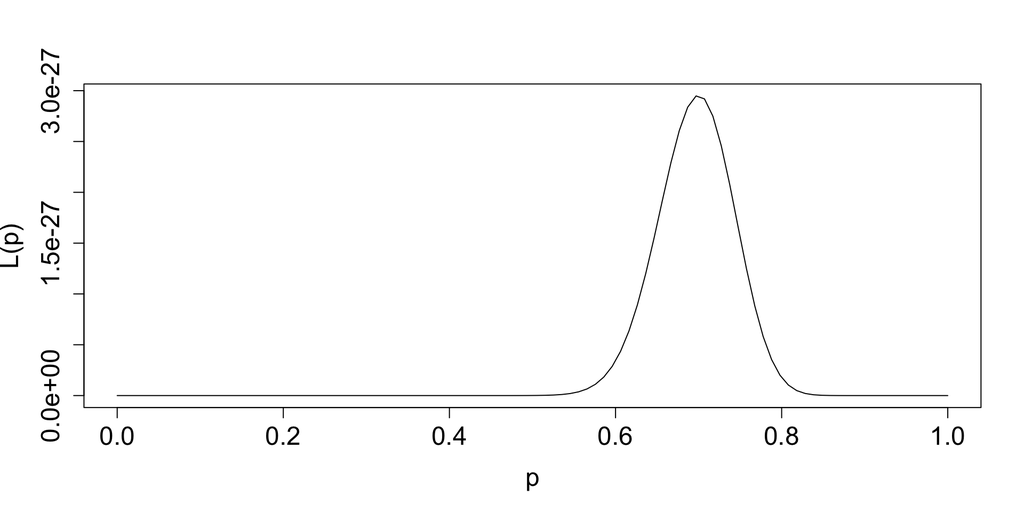

## General mechanics for finding the MLE

1. Assume a distribution for the population
2. Define the likelihood: joint probability of the data
3. Take the log of the likelihood
4. Find the value of $\theta$ that maximizes the likelihood:
   1. Differentiate the log-likelihood with respect to $\theta$
   2. Set the derivative to 0
   3. Solve for $\theta$

## Example

$L(p) = \prod_{i=1}^{n}p^{x_i} (1-p)^{1-x_i}$

## Evaluating Estimators

- Bias: Average distance from the population parameter
  - Bias($\hat{\theta}$) = $\mathbf{E}[\hat{\theta}]-\theta$
- Standard Error (SE): standard deviation of the estimator (i.e., SD of the sampling distribution)
  - STD($\hat{\theta}$)= $\sqrt{\mathbf{E}[\hat{\theta}-\mathbf{E}(\hat{\theta})]^2}$
- Mean Squared Error (MSE): combines standard error and bias
  - MSE($\hat{\theta}$)= $\mathbf{E}[\hat{\theta}-\theta]^2$ = SE$^2$ + Bias$^2$
- Consistency: the estimate converges to the true value as $n \rightarrow \infty$

## Evaluating Estimators

## Example

Let $X_1, X_2, ..., X_n \stackrel{iid}{\sim} Poisson(\lambda)$

Derive the MLE, $\hat{\lambda}$, and determine if this is an unbiased estimator of $\lambda$

$P(X=x)=\frac{\lambda^x e^{-\lambda}}{x !}$